# KECK Team 4

Chloe MT Keck

4/27/2022

### Introduction

For this section of the Hack-a-thon, we examined the relationship between water use and priority ranking of the impared waterbodies in the 2018 data set. `use` can either be `SHELLFISH`, referring to shellfish consumption; `REC`, referring to recreational use such as swimming; `FISH`, referring to fish consumption; or `AL`, referring to aquatic life. Priority ranking ranges between 1-3, each level corresponding to the severity of impairment.

1 = **Current Priorities** are those site/pollutant combinations being addressed by TMDL or alternative restoration plans being developed during the 2016-2018 time-frame.

2 = **Near-Term Priorities** are those site/pollutant combinations being addressed by TMDL or alternative restoration plans being developed during the 2019-2022 time-frame.

3 = **Long-Term Priorities** are those site/pollutant combinations being addressed by TMDL or alternative restoration plans being developed after 2022.

### Use vs. priority ranking

WHen examining th erelationship between use and priority ranking, we visualized the data below using a histogram.

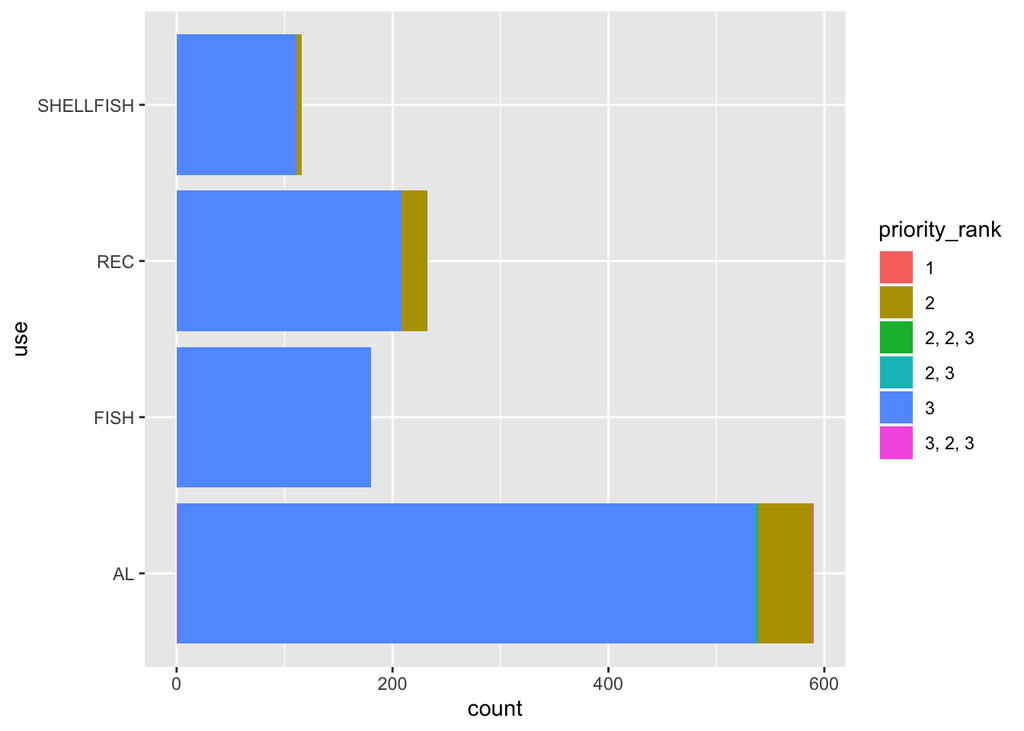

```r
ggplot(data = imp) +
  geom_histogram(aes(x = use, fill = priority_rank), stat = "count", binwidth = 5) +
  coord_flip()
```

To get a closer look, we created a histogram examining the distribution of priority ranking for each of the uses.

### SHELLFISH

The impaired water bodies designated for shellfish consumption were composed of almost entirely priority 3, meaning the impairment will be addressed at a later date.

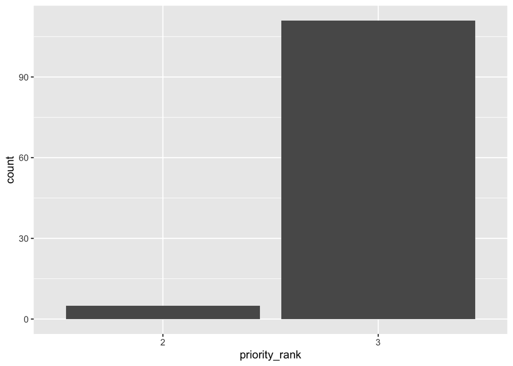

```r
imp_SHELLFISH = imp %>%
  filter(use =="SHELLFISH")

ggplot(data = imp_SHELLFISH) +
  geom_histogram(aes(x = priority_rank), stat = "count", binwidth = 5)
```

### FISH

Similar to shellfish consumption, fish consumption sites are all labeled as level 3 priority ranking.

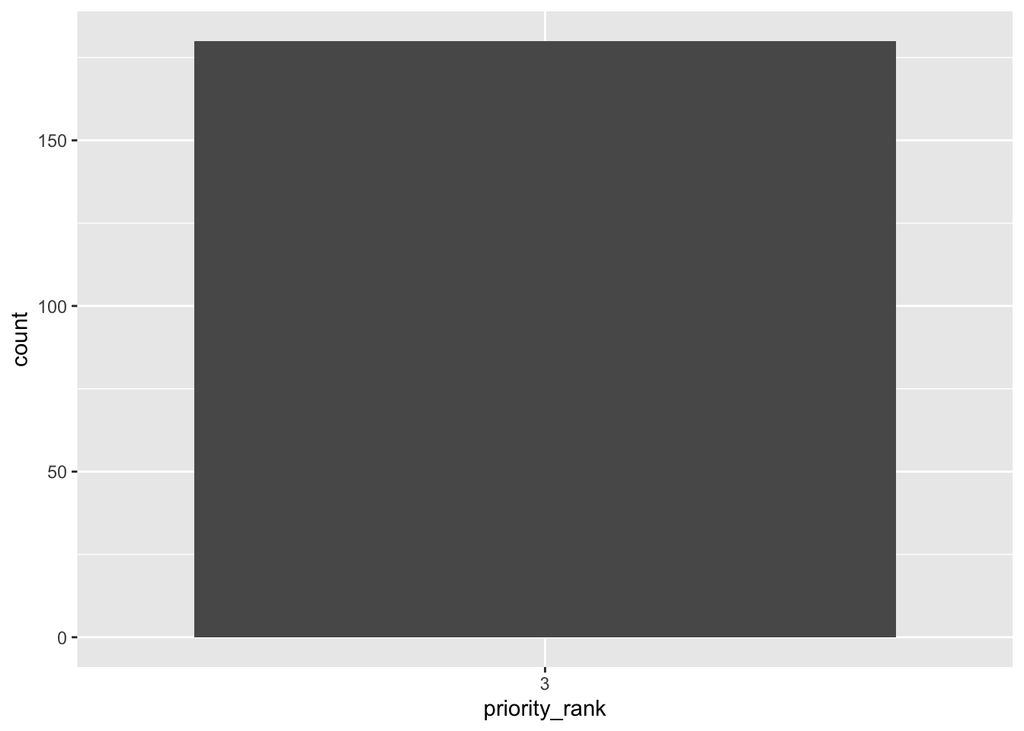

```r
imp_FISH = imp %>%
  filter(use == "FISH")

ggplot(data = imp_FISH) +
  geom_histogram(aes(x = priority_rank), stat = "count", binwidth = 5)
```

### REC

Recreationally used impared waters had a slightly higher amount of 2 priority ranks; however, recreation is still mostly composed of water bodies with a 3 priority rank.

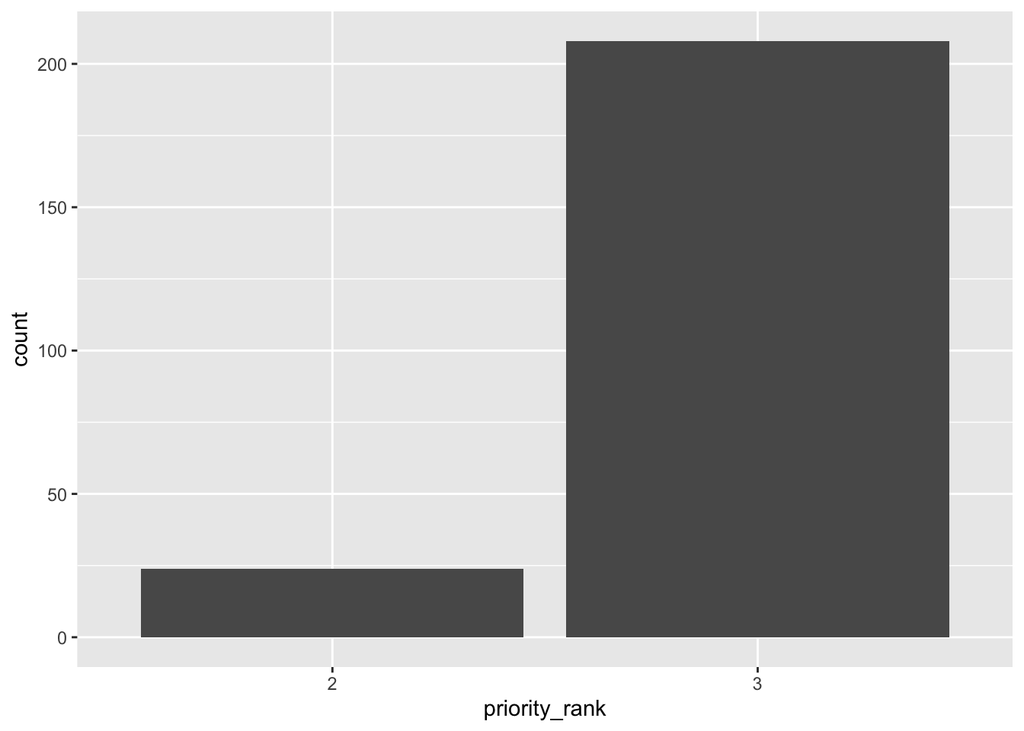

```r
imp_REC = imp %>%
  filter(use == "REC")

ggplot(data = imp_REC) +
  geom_histogram(aes(x = priority_rank), stat = "count", binwidth = 5)
```

### AL

Aquatic life use has the most variable priority rankings. **Aquatic life contains the only impairment listed as a priority ranking of 1**. Additionally, five of the impaured bodies are listed as multiple priority rankings (i.e. `2,2,3`; `2, 3`; and `3,2,3`). According to these data, **the aquatic life use is both the most variable and the most prioritized impairment use**.

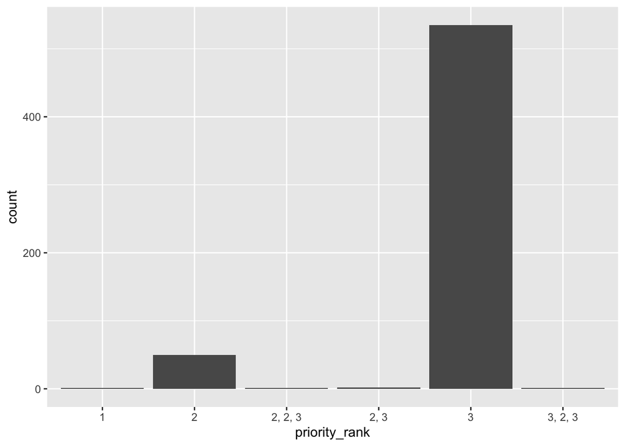

```r
imp_AL = imp %>%
  filter(use == "AL")

ggplot(data = imp_AL) +
  geom_histogram(aes(x = priority_rank), stat = "count", binwidth = 5)
```